# Global Clustering Based On Time Series Features

Clustering is a common unsupervised learning approach. The problem with time series is that the notion of “distance” between time series isn’t as straight forward as it is for independent multidimensional data points. Common distance metrics like euclidean or Manhattan distance don’t necessarily tell you about how close two different time series are and in many cases the results of those computations would go against the human intuition. A way to still use clustering algorithms (and classification algorithms for that matter) on time series data sets is to compute time series features - metrics like the first local extreme points, points below the mean, etc - and use all of those features in place of the original (univariate) time series.

In this document we try to apply this method on the stock data we collected in the data acquisition document. We will try to find meaningful clusters of tickers, look at their composition (which kind of companies can be found in these clusters) and at differences in their performance.

## Data Preparation

The chosen tickers currently aren’t on the same scale. We can remedy this by normalizing all values for each symbol. We’ll focus on the adjusted price which is the closing price after corrections for splits and dividend distributions.

```r
prices <- ticker_data %>%
  select(price.adjusted, ticker) %>%
  fill_gaps() %>%
  fill(price.adjusted, .direction = "down") %>%
  group_by(ticker) %>%
  mutate(standardized_price = (price.adjusted - mean(price.adjusted)) / sd(price.adjusted)) %>%
  ungroup() %>%
  select(-price.adjusted)

prices
```

| ticker | ref.date | standardized_price |
| --- | --- | --- |
| AAPL | 1999-01-04 | -0.6789275 |
| AAPL | 1999-01-05 | -0.6783390 |
| AAPL | 1999-01-06 | -0.6787849 |
| AAPL | 1999-01-07 | -0.6778576 |
| AAPL | 1999-01-08 | -0.6778576 |
| AAPL | 1999-01-09 | -0.6778576 |
| AAPL | 1999-01-10 | -0.6778576 |
| AAPL | 1999-01-11 | -0.6776080 |
| AAPL | 1999-01-12 | -0.6775366 |
| AAPL | 1999-01-13 | -0.6774296 |

[output cut: 990 more lines]

Looking at all 216 symbols we can see similarities regarding big economic trends (bang/bust cycles and long time upward trend) as well as individual differences (a lot of steady values compared to more volatile stocks). We expect the chosen stocks to show some common characteristics as the selection criteria are rather stringent. Each title had to be part of the S&P 500 at one point in time during the last 30 years while also having data from 1999 to 2021. This favors established companies over new titles (left censoring) while also favoring extremely vetted stocks over the general population of traded titles (biased sample).

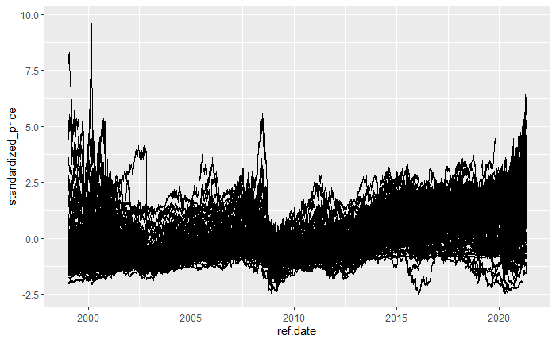

```r
prices %>%
  ggplot(aes(x = ref.date, standardized_price, group = ticker)) +
  geom_line()
```

## Time Series Feature Computation

Working with raw time series values is both computationally expensive as well as generally hard to do right. To circumvent these problems researchers of all fields that use time series data have been doing extensive work to find features which represent time series as a vector of comparable features. One of those efforts culminated into the [Highly comparative time-series analysis package](https://github.com/benfulcher/hctsa) which allows to compute over 7000 features. Based on this work the researchers behind the [catch22 package](https://github.com/chlubba/catch22) selected 22 features which - on average - offer the best cost/benefit trade-off in regarding general time series clustering and classification tasks. As we do not have in-depth knowledge of econometrics we decided to go with the `catch22` set of features rather than hand-picking the best set of features ourselves.

```r
features_for_price_range <- function(price_range) {
  price_range %>%
    features(standardized_price,
             list(~ catch22_all(.) %>% pivot_wider(names_from = names, values_from = values)))
}

c22_price_feats <- features_for_price_range(prices)
c22_price_feats
```

| ticker | DN_HistogramMode_5 | DN_HistogramMode_10 | CO_f1ecac | CO_FirstMin_ac | CO_HistogramAMI_even_2_5 | CO_trev_1_num | MD_hrv_classic_pnn40 | SB_BinaryStats_mean_longstretch1 | SB_TransitionMatrix_3ac_sumdiagcov | PD_PeriodicityWang_th0_01 | CO_Embed2_Dist_tau_d_expfit_meandiff | IN_AutoMutualInfoStats_40_gaussian_fmmi | FC_LocalSimple_mean1_tauresrat | DN_OutlierInclude_p_001_mdrmd | DN_OutlierInclude_n_001_mdrmd | SP_Summaries_welch_rect_area_5_1 | SB_BinaryStats_diff_longstretch0 | SB_MotifThree_quantile_hh | SC_FluctAnal_2_rsrangefit_50_1_logi_prop_r1 | SC_FluctAnal_2_dfa_50_1_2_logi_prop_r1 | SP_Summaries_welch_rect_centroid | FC_LocalSimple_mean3_stderr |
| --- | --- | --- | --- | --- | --- | --- | --- | --- | --- | --- | --- | --- | --- | --- | --- | --- | --- | --- | --- | --- | --- | --- |
| AAPL | -0.153652045 | -0.418431051 | 987 | 4593 | 0.7087197 | -3.335996e-07 | 0.03652408 | 2566 | 0.166666667 | 903 | 2.5427597 | 40 | 0.0003473428 | 0.94963235 | -0.471323529 | 0.9986286 | 6 | 1.118021 | 0.20 | 0.22 | 0.0015339808 | 0.02539111 |
| ABT | -0.436446245 | -0.676807266 | 1059 | 5471 | 0.9921349 | 4.614729e-06 | 0.04142665 | 2760 | 0.166666667 | 0 | 3.0878473 | 40 | 0.0003664346 | 0.90962010 | -0.446752451 | 0.9988994 | 6 | 1.135461 | 0.12 | 0.14 | 0.0015339808 | 0.02500712 |
| ADM | -0.080906650 | -1.290844080 | 1518 | 1935 | 1.1912048 | -1.351260e-05 | 0.12354455 | 3005 | 0.166666667 | 2675 | 3.2863584 | 40 | 0.0003508772 | 0.78449755 | -0.710906863 | 0.9986717 | 6 | 1.155311 | 0.22 | 0.86 | 0.0007669904 | 0.03728115 |
| ADP | -0.510917757 | -0.715969883 | 1311 | 4446 | 1.0703853 | -1.540086e-05 | 0.04142665 | 2647 | 0.074074074 | 0 | 2.0420093 | 40 | 0.0003923107 | 0.86544118 | -0.433088235 | 0.9990368 | 6 | 1.164817 | 0.12 | 0.14 | 0.0007669904 | 0.02548862 |
| ADSK | -0.336412265 | -0.593513394 | 958 | 3095 | 0.7311121 | -8.140829e-06 | 0.05637946 | 1760 | 0.074074074 | 2253 | 2.7635598 | 40 | 0.0004106776 | 0.94264706 | -0.626102941 | 0.9987198 | 6 | 1.155121 | 0.28 | 0.18 | 0.0015339808 | 0.03084189 |
| AEE | -0.744862761 | -0.539293221 | 1121 | 3066 | 1.2206919 | -1.128805e-05 | 0.05208972 | 2408 | 0.074074074 | 0 | 1.6005722 | 40 | 0.0004498426 | 0.86862745 | -0.615196078 | 0.9990755 | 6 | 1.148575 | 0.58 | 0.14 | 0.0015339808 | 0.02882282 |
| AEP | -0.782624899 | -0.576079111 | 1450 | 4362 | 1.2293970 | -4.932968e-06 | 0.04608408 | 2753 | 0.074074074 | 0 | 2.4210584 | 40 | 0.0011441648 | 0.85006127 | -0.565563725 | 0.9993216 | 6 | 1.155752 | 0.12 | 0.12 | 0.0007669904 | 0.02745401 |
| AIG | -0.609806669 | -0.768035337 | 1624 | 4657 | 1.0126549 | -4.755154e-06 | 0.06814561 | 3461 | 0.111111111 | 2369 | 4.1137876 | 40 | 0.0015031943 | -0.58700980 | 0.433578431 | 0.9995889 | 6 | 1.179674 | 0.14 | 0.12 | 0.0007669904 | 0.02699716 |
| AIT | -0.731506648 | -0.972139337 | 1556 | 397 | 1.0667390 | -2.130746e-05 | 0.09106508 | 3417 | 0.166666667 | 1462 | 1.7594485 | 40 | 0.0003434066 | 0.79313725 | -0.658639706 | 0.9986376 | 6 | 1.156501 | 0.26 | 0.12 | 0.0007669904 | 0.03428174 |
| ALL | -0.820719493 | -0.595276636 | 1218 | 3048 | 1.2056154 | -2.444034e-05 | 0.06091433 | 2633 | 0.074074074 | 0 | 2.2209694 | 40 | 0.0004498426 | 0.82935049 | -0.597977941 | 0.9989284 | 6 | 1.159427 | 0.12 | 0.14 | 0.0015339808 | 0.03034527 |

[output cut: 206 more lines]

Similar to “traditional” clustering and classification tasks we decided to normalize the features to bring them on the same scale.

```r
prep_rec <- recipe(~ ., data = c22_price_feats) %>%
  step_normalize(all_numeric()) %>%
  prep()


prepare_price_range <- function(featurized_prices, .rec) {
  .rec %>%
    bake(featurized_prices) %>%
    column_to_rownames("ticker") %>%
    # remove nulls because two columns are almost always constant for all observations
    select(-c(IN_AutoMutualInfoStats_40_gaussian_fmmi, SB_BinaryStats_diff_longstretch0)) %>%
    as.data.frame()
}

prepped_data <- c22_price_feats %>%
  prepare_price_range(.rec = prep_rec)
```

## K-Means Clustering

Without any indicators about the “right” amount of clusters and no prior knowledge in econometrics or trading we decided to try k-means clustering to see if there are obvious clusters within our data set.

```r
set.seed(1337)

centers <- c()
withinsss <- c()

for (center in 1:15) {
  kclust <- kmeans(prepped_data, centers = center, nstart = 10)
  twss <- kclust %>% glance() %>% (function (x) x$tot.withinss)

  centers[center] <- center
  withinsss[center] <- twss
}

kclust_res <- tibble(Centers = centers, TotalWithinss = withinsss)
kclust_res
```

| Centers | TotalWithinss |
| --- | --- |
| 1 | 4300.000 |
| 2 | 3151.993 |
| 3 | 2860.872 |
| 4 | 2631.247 |
| 5 | 2460.106 |
| 6 | 2358.703 |
| 7 | 2208.417 |
| 8 | 2135.113 |
| 9 | 2015.458 |
| 10 | 1929.045 |

[output cut: 5 more lines]

To get a rough estimate about the number of valid clusters we computed clusters with 1 to 15 centroids and compared the `withinss` measure. A visual analysis shows the anticipated elbow at $k=2$.

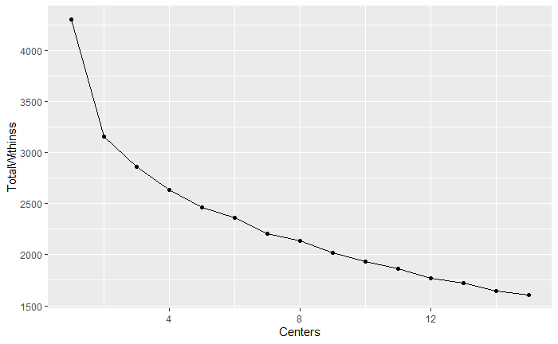

```r
ggplot(kclust_res, aes(x = Centers, y = TotalWithinss)) +
  geom_point() +
  geom_line()
```

Creating a cluster with two centroids shows a rather unbalanced distribution of 170 versus 46 cluster members.

```r
opt_clust <- kmeans(prepped_data, centers = 2, nstart = 10)

cluster_sizes <- opt_clust %>% tidy() %>% (function (x) x$size) # your cluster sizes
cluster_sizes
```

```
[1] 170  46
```

As we don’t see the temporal patterns in the feature-vector representation we join the cluster labels with our normalized price dataset and plot the time series in their respective clusters. We still see the the cycle and trend components in both clusters while also getting the sense of a possible sensible partition between stocks with certain high volatility behavior and stocks that show less movement in their price development.

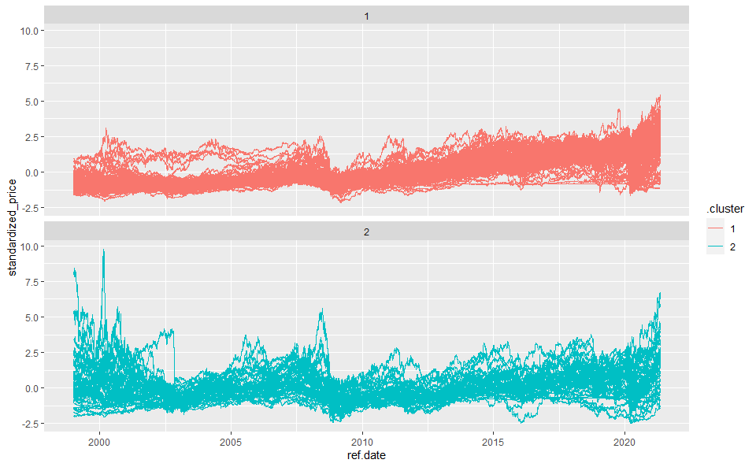

```r
clustered_data <- augment(opt_clust, prepped_data) %>%
  rename(ticker = .rownames)

join_cluster_with_price_range <- function(.clustered, .price_range) {
  .price_range %>%
    left_join(.clustered %>% select(ticker, .cluster), by = "ticker")
}

plot_clustered_tickers <- function(.clustered) {
  nrow <- .clustered$.cluster %>%
    unique() %>%
    length()

  ggplot(.clustered, aes(x = ref.date, standardized_price, group = ticker, color = .cluster)) +
    geom_line() +
    facet_wrap(~ .cluster, nrow = nrow)
}

clustered_data %>%
  join_cluster_with_price_range(.price_range = prices) %>%
  plot_clustered_tickers()
```

We were able to collect additional metadata containing information about the business sectors of certain titles within our data set. Looking at this data, we are particularly interested in the relative composition of our clusters. As we can see in the resulting figure there are striking differences but unfortunately the fraction of “unknown” sectors in the second cluster is far too high to base any interpretation on this result.

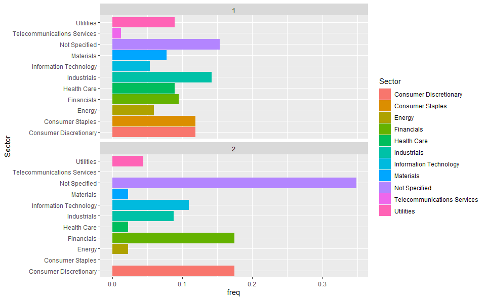

```r
enrich_with_meta <- function(clustered_prices) {
  clustered_prices %>%
    left_join(ticker_meta, by = c("ticker" = "Symbol")) %>%
    replace_na(list(Sector = "Not Specified", Subsector = "Not Specified"))
}

sector_freq_per_cluster <- function(enriched_prices) {
  nrow <- enriched_prices$.cluster %>%
    unique() %>%
    length()

  enriched_prices %>%
    group_by(.cluster, Sector) %>%
    summarise(count = n()) %>%
    mutate(freq = count / sum(count)) %>%
    ggplot(aes(x = Sector, y = freq, color = Sector, fill = Sector)) +
    geom_col() +
    facet_wrap(~ .cluster, nrow = nrow) +
    coord_flip()
}

clustered_data %>%
  enrich_with_meta() %>%
  sector_freq_per_cluster()
```

### Further Dimensionality Reduction

In order to even further reduce the dimensions of our already rather slim feature vectors we decided to try a primary component anlysis.

```r
pca_estimates <- recipe(~., data = prepped_data) %>%
  step_pca(all_numeric(), num_comp = NCOL(prepped_data)) %>%
  prep()

extract_pca_components <- function(.df, .rec) {
  components <- .rec %>%
    bake(.df) %>%
    as.data.frame()

  rownames(components) <- rownames(.df)
  components
}

components <- extract_pca_components(prepped_data, pca_estimates)
components
```

|  | PC01 | PC02 | PC03 | PC04 | PC05 | PC06 | PC07 | PC08 | PC09 | PC10 | PC11 | PC12 | PC13 | PC14 | PC15 | PC16 | PC17 | PC18 | PC19 | PC20 |
| --- | --- | --- | --- | --- | --- | --- | --- | --- | --- | --- | --- | --- | --- | --- | --- | --- | --- | --- | --- | --- |
| AAPL | 1.339362591 | 2.787307064 | -1.222740477 | -1.216470205 | -0.293675199 | -0.699193598 | -0.97069619 | 0.113852680 | 0.287704163 | -1.32980641 | 0.2051565254 | 0.150961598 | 0.39076240 | 0.581363308 | 0.529489523 | -0.470501849 | 0.2273888971 | -0.762221871 | 0.3869061163 | -0.3859681813 |
| ABT | 2.235637513 | 1.943452209 | -0.133230798 | -1.408359886 | -0.377031874 | -0.418228600 | -1.02072657 | -0.175904180 | 0.171957266 | -0.40529876 | -0.4260507918 | 0.587584309 | 1.07695724 | 0.078521913 | 0.869822045 | -0.099894186 | -0.2284267967 | -0.712986905 | 0.1477044863 | -0.0800503953 |
| ADM | 1.459864450 | -1.113022201 | -1.090986806 | 1.358462180 | 0.582646406 | -1.592963118 | -1.14758752 | -1.025648713 | 0.870777634 | -1.13683236 | -1.7518687738 | -0.672670540 | 0.48272034 | 0.137062610 | -0.371725300 | -0.106257295 | -0.0540422711 | -0.538546640 | -0.0138130182 | 0.0467461964 |
| ADP | 1.654422349 | 0.870779578 | 0.233229306 | -1.390101593 | -0.156698419 | 0.574848702 | -0.13296648 | 0.078320224 | 0.439773435 | 0.83809451 | -0.0664480049 | 0.387616921 | -0.32307464 | 0.135452734 | -0.350510098 | -0.101220374 | 0.3180674769 | 0.187975081 | -0.2921850303 | 0.0395082351 |
| ADSK | 0.129510779 | 1.507155996 | -1.170962280 | -0.645632398 | -1.104650068 | -0.817127752 | 0.59239580 | -0.721253275 | 1.481035421 | -0.93383755 | 0.5980170929 | 0.307379417 | -0.36804180 | -0.304518880 | 0.083077898 | -0.513217000 | 0.0173524953 | -0.135824160 | 0.2942520515 | -0.0692640737 |
| AEE | 0.918058297 | 1.158827287 | 0.878779820 | -0.286556673 | 0.341327562 | 1.692300936 | 0.62350055 | 0.030065429 | 0.163407952 | -0.30090317 | 0.9919651915 | -0.129853357 | -0.12306063 | 0.025951355 | 0.207559518 | 0.366198427 | -0.7121263875 | -0.021726589 | -0.2469651371 | 0.0198854350 |
| AEP | 2.216648609 | 0.237515673 | 0.964967321 | -1.370898848 | -0.409396464 | 0.672389310 | 0.15036349 | -0.521224189 | -0.436491804 | 0.39596470 | 0.1009549655 | 0.190028800 | -0.01311155 | -0.153723511 | -0.147503080 | -0.052972957 | 0.4387429803 | 0.328974481 | 0.0051659173 | 0.2334477835 |
| AIG | 1.419058916 | -0.395274006 | 2.333364227 | -1.515849960 | -0.864592552 | -4.414774050 | 0.69509929 | 1.339671801 | -0.367064044 | 0.19175580 | -1.3859615770 | 0.240588763 | 0.61459356 | -0.275800864 | -0.369874620 | -0.374482387 | 0.3100899369 | 0.212336817 | 0.1819139286 | -0.1098570921 |
| AIT | 1.778970502 | 0.285414102 | -0.897496353 | 1.792702966 | -0.137020667 | 0.062766319 | 0.04243874 | 0.600108345 | -0.915541248 | 0.21845750 | -0.3415586803 | 0.081917737 | -0.13024795 | 0.644956525 | -0.553441865 | -0.390831878 | -0.1567485998 | -0.475000449 | -0.0431058507 | -0.2264977057 |
| ALL | 1.258860803 | 0.722198429 | 0.233272883 | -0.872846331 | -0.482469966 | 0.899185671 | 0.21455808 | -0.639079156 | -0.334097253 | 0.83112294 | 0.1645981389 | -0.046943159 | 0.21367274 | -0.130671463 | 0.177974262 | -0.024311204 | -0.6393531112 | 0.136224948 | -0.1154833031 | 0.1229491863 |

[output cut: 206 more lines]

Looking at the percentages of variation each component explains we can see that the amount of explained variation rapidly decreases. This indicates, that we can most likely only work on a subset of components without loosing a lot of information.

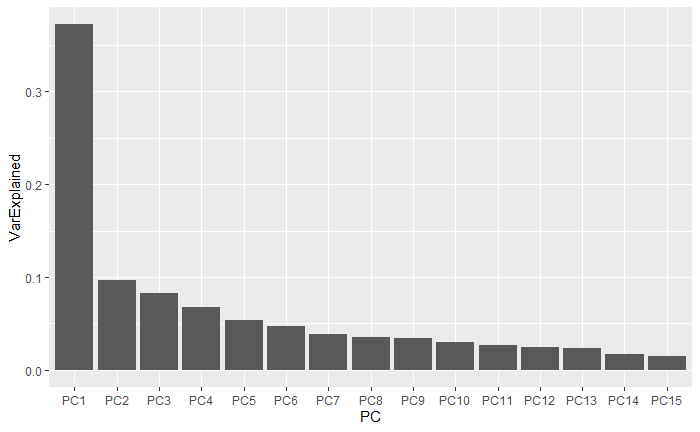

```r
stdev <- pca_estimates$steps[[1]]$res$sdev
percent_variation <- stdev ^ 2 / sum(stdev ^ 2)

variations <- tibble(PC = paste0("PC", 1:length(stdev)),
                     VarExplained = percent_variation)

explained <- 0
n_comps_for_095 <- 0
for (row in 1:NROW(variations)) {
  explained <- explained + variations$VarExplained[row]
  n_comps_for_095 <- n_comps_for_095 + 1
  if (explained >= 0.95) {
    break;
  }
}

variations %>%
  mutate(PC = forcats::fct_inorder(PC)) %>%
  # just take the first 20 because the rest doesn't matter too much anyway
  # and the plot gets very hard to read otherwise
  slice_head(n = n_comps_for_095) %>%
  ggplot(aes(x = PC, y = VarExplained)) +
  geom_col()
```

As 15 explain 96.2265132% of the variability in our data set we can throw out the last 5 components. With this additional preprocessing step in place we decided to repeat our initial k-means cluster analysis which led to a very similar result. We take this as a further indication that $k=2$ is valid.

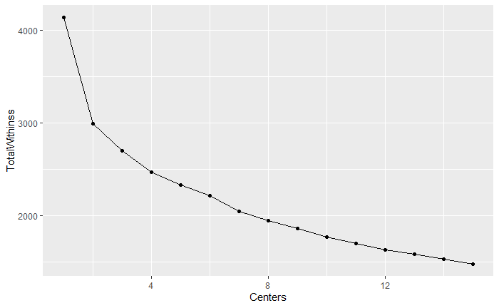

```r
set.seed(1337)

pca_96_perc_rec <- recipe(~., data = prepped_data) %>%
  step_pca(all_numeric(), num_comp = 15) %>%
  prep()

reduced_components <- extract_pca_components(prepped_data, pca_96_perc_rec)

centers <- c()
withinsss <- c()

for (center in 1:15) {
  kclust <- kmeans(reduced_components, centers = center, nstart = 10)
  twss <- kclust %>% glance() %>% (function (x) x$tot.withinss)

  centers[center] <- center
  withinsss[center] <- twss
}

kclust_res <- tibble(Centers = centers, TotalWithinss = withinsss)

ggplot(kclust_res, aes(x = Centers, y = TotalWithinss)) +
  geom_point() +
  geom_line()
```

Looking only at the first and the second component we can see that there appears pretty high certainty about the first cluster, which appears to be rather dense while the second cluster has very fuzzy boundaries and less density.

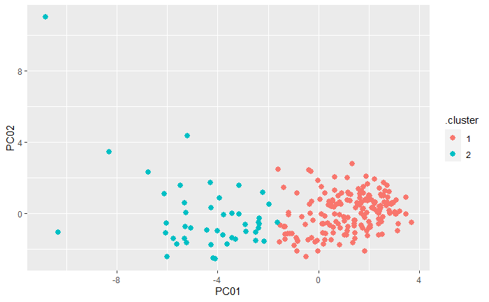

```r
set.seed(1337)

pca_clust <- kmeans(reduced_components, nstart = 10, centers = 2)

clustered_components <- augment(pca_clust, components)

ggplot(clustered_components, aes(x = PC01, y = PC02, color = .cluster)) +
  geom_point(size = 2.5)
```

## Clustering via HDBSCAN

The problem with k-means (and many other clustering algorithms) is, that regardless of whether clusters are valid or not it will form exactly as many clusters as there are configured centroids. DBSCAN and HDBSCAN (a hierarchical clustering algorithm based on DBSCAN) are alternative algorithms that - in addition to finding clusters and classifying observations accordingly - can mark observations as outliers if they don’t fit any cluster. Using HDBSCAN on our normalized data set (without PCA) would yield two clusters, one containing the majority of all observations and one containing only four time series. The rest - 60 time series in total - would be classified as “too fringe” to be part of any cluster.

```r
library(dbscan)
set.seed(1337)

hdb <- dbscan::hdbscan(prepped_data, minPts = 4)
hdb
```

```
HDBSCAN clustering for 216 objects.
Parameters: minPts = 4
The clustering contains 2 cluster(s) and 60 noise points.

  0   1   2
 60   4 152

Available fields: cluster, minPts, cluster_scores, membership_prob, outlier_scores, hc
```

As HDBSCAN is a hierarchical algorithm we can look at its dendrogram. Given that we configured a minimum cluster size of 4 observations the smallest found cluster contains exactly 4 observations.

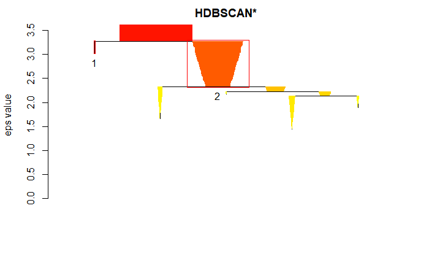

```r
plot(hdb, show_flat = TRUE)
```

In contrast to the k-means clustering we see that the time series clustered together have to be far more similar to actually land into the same cluster.

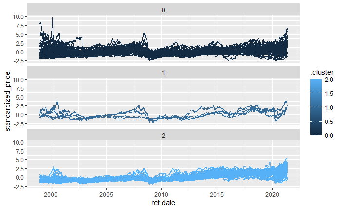

```r
clustered_data <- bind_cols(prepped_data, list(.cluster = hdb$cluster)) %>%
  rownames_to_column("ticker")

clustered_data %>%
  join_cluster_with_price_range(.price_range = prices) %>%
  plot_clustered_tickers()
```

### The Effects of Dimensionality Reduction on HDBSCAN

As we did in the k-means experiment we also decided to use the HDBSCAN algorithm on the data set we reduced by performing a PCA on the normalized feature vectors. As we can see this preprocessing allowed us to increase the minimum size of observations per cluster while still getting decently sized clusters. As a trade-off the amount of outlier observations dramatically increased. From our point it is hard to say what would make more sense in regard to the financial domain. From our statistical intuition we would assume that a bigger minimum of observations per cluster should result in more valid clusters. Because of this we will use dimensionality reduction in the rest of the analysis.

```r
set.seed(1337)

hdb <- dbscan::hdbscan(reduced_components, minPts = 6)
hdb
```

```
HDBSCAN clustering for 216 objects.
Parameters: minPts = 6
The clustering contains 2 cluster(s) and 162 noise points.

  0   1   2
162  14  40

Available fields: cluster, minPts, cluster_scores, membership_prob, outlier_scores, hc
```

As before we can also inspect the dendrogram, which appears to be flatter and more “balanced” than in our first HDBSCAN experiment.

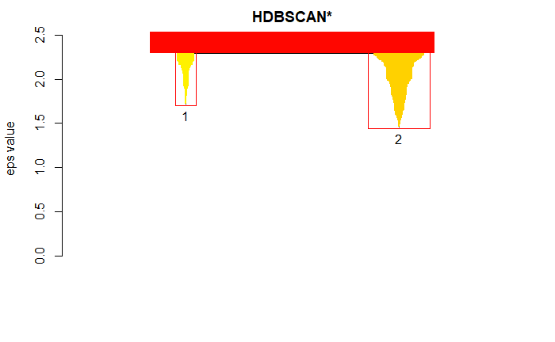

```r
plot(hdb, show_flat = TRUE)
```

As for the clusters there appears to be an even higher similarity between the time series in each cluster.

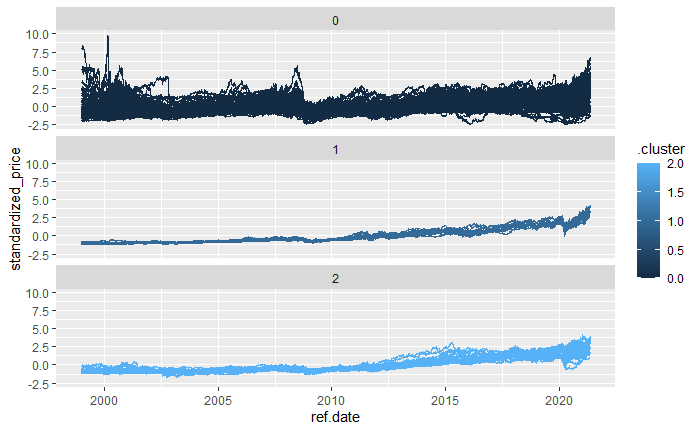

```r
perform_clustering <- function(.ds, .minPts = 6) {
  set.seed(1337)
  hdb <- dbscan::hdbscan(.ds, minPts = .minPts)

  bind_cols(.ds, list(.cluster = hdb$cluster)) %>%
    rownames_to_column("ticker")
}

clustered_data <- reduced_components %>%
  perform_clustering()

clustered_data %>%
  join_cluster_with_price_range(.price_range = prices) %>%
  plot_clustered_tickers()
```

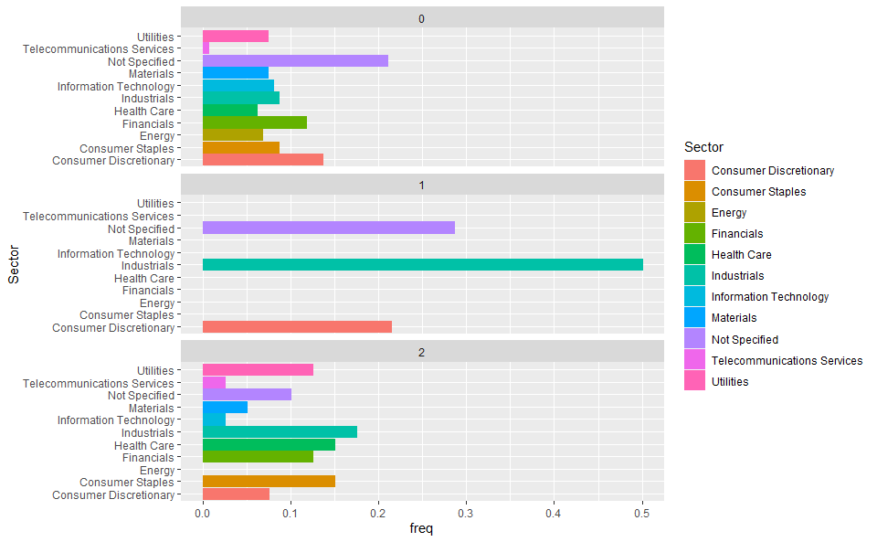

```r
clustered_data %>%
  enrich_with_meta() %>%
  sector_freq_per_cluster()
```

In comparison to the relative composition of the complete sample we can see that the disperse group of outlier observations is relatively similar while the two different clusters are distinctly different.

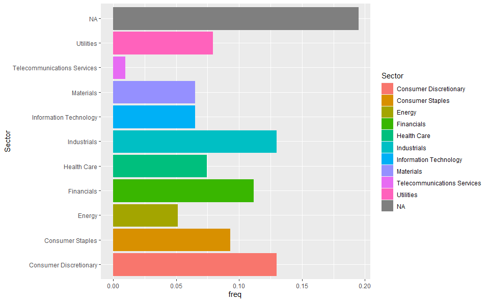

```r
ticker_meta %>%
  group_by(Sector) %>%
  summarise(count = n()) %>%
  mutate(freq = count / sum(count)) %>%
  ggplot(aes(x = Sector, y = freq, color = Sector, fill = Sector)) +
  geom_col() +
  coord_flip()
```

## Exploring Differences in (Financial) Cluster Performance

As we can see above we can already see distinct differences in business sectors which contribute to each cluster. Another interesting piece of additional information for us would be if the clusters we found perform differently from their base index: the S&P 500.

To compare the differences we make use of the `tidyquant` library, a package that includes common functionality used by “quants” (quantitative financial analysts). One of these common functionalities is to calculate the return over a period (in this case monthly) for a set of assets. In the following example we calculate the monthly returns of all tickers in our biggest cluster.

```r
get_tickers_for_cluster <- function(.clustered, .clust_num) {
  .clustered %>%
    filter(.cluster == .clust_num) %>%
    select(ticker) %>%
    (function(x) x$ticker)
}

clust_two_symbols <- get_tickers_for_cluster(clustered_data, 2)

get_mreturns_per_ticker_in_range <- function(.tickers, .price_range) {
  min_date <- format(min(.price_range$ref.date), "%Y-%m-%d")
  max_date <- format(max(.price_range$ref.date), "%Y-%m-%d")

  ticker_data %>%
    filter(ticker %in% .tickers) %>%
    filter_index(min_date ~ max_date) %>%
    rename(date = ref.date) %>%
    tibble() %>%
    group_by(ticker) %>%
    tq_transmute(select = price.adjusted,
                 mutate_fun = periodReturn,
                 period = "monthly",
                 col_rename = "Ra")
}

Ra <- get_mreturns_per_ticker_in_range(clust_two_symbols, prices)
Ra
```

| ticker | date | Ra |
| --- | --- | --- |
| ADP | 1999-01-29 | 0.0493064795 |
| ADP | 1999-02-26 | -0.0660793042 |
| ADP | 1999-03-31 | 0.0428736028 |
| ADP | 1999-04-30 | 0.0755283201 |
| ADP | 1999-05-28 | -0.0744380996 |
| ADP | 1999-06-30 | 0.0702400360 |
| ADP | 1999-07-30 | -0.0894885549 |
| ADP | 1999-08-31 | -0.0187205487 |
| ADP | 1999-09-30 | 0.1372142731 |
| ADP | 1999-10-29 | 0.0798323904 |

[output cut: 990 more lines]

In order to see if our cluster of interest performs better or worse, than the index we have to first retrieve the same returns for the S&P 500. The symbol in question would be `^GSPC`.

```r
get_baseline_mreturns_in_range <- function(.price_range) {
  min_date <- format(min(.price_range$ref.date), "%Y-%m-%d")
  max_date <- format(max(.price_range$ref.date), "%Y-%m-%d")

  "^GSPC" %>% # S&P 500 is baseline for the clusters
    tq_get(get = "stock.prices",
           from = min_date,
           to = max_date) %>%
    tq_transmute(select = adjusted,
                 mutate_fun = periodReturn,
                 period = "monthly",
                 col_rename = "Rb")
}

Rb <- get_baseline_mreturns_in_range(prices)
Rb
```

| date | Rb |
| --- | --- |
| 1999-01-29 | 4.196730e-02 |
| 1999-02-26 | -3.228256e-02 |
| 1999-03-31 | 3.879422e-02 |
| 1999-04-30 | 3.794403e-02 |
| 1999-05-28 | -2.497048e-02 |
| 1999-06-30 | 5.443833e-02 |
| 1999-07-30 | -3.204609e-02 |
| 1999-08-31 | -6.254092e-03 |
| 1999-09-30 | -2.855179e-02 |
| 1999-10-29 | 6.253954e-02 |

[output cut: 259 more lines]

We can use `tidyquant` to calculate the performance using the monthly returns of our cluster assets as well as the baseline. Unfortunately we would need access to real domain experts for a thorough analysis of the results. As we are not “quants” ourselves we focus on the most intuitive value in the result data set which would be the active premium. The active premium is calculated by subtracting the baseline annualized returns from the asset annualized returns. So - being very reductive - a higher active premium indicates a better performance.

```r
ticker_performance_against_baseline_in_range <- function(.tickers, .price_range) {
  Ra <- get_mreturns_per_ticker_in_range(.tickers, .price_range)
  Rb <- get_baseline_mreturns_in_range(.price_range)
  RaRb <- left_join(Ra, Rb, by = "date")

  RaRb %>%
    tq_performance(Ra = Ra,
                   Rb = Rb,
                   performance_fun = table.CAPM)
}

RaRb_capm <- ticker_performance_against_baseline_in_range(clust_two_symbols, prices)
RaRb_capm
```

| ticker | ActivePremium | Alpha | AnnualizedAlpha | Beta | Beta- | Beta+ | Correlation | Correlationp-value | InformationRatio | R-squared | TrackingError | TreynorRatio |
| --- | --- | --- | --- | --- | --- | --- | --- | --- | --- | --- | --- | --- |
| ADP | 0.0479 | 0.0056 | 0.0690 | 0.8163 | 0.7807 | 0.8866 | 0.5888 | 0.0000 | 0.2812 | 0.3467 | 0.1704 | 0.1298 |
| AEP | 0.0195 | 0.0058 | 0.0725 | 0.3623 | 0.6025 | 0.0563 | 0.2669 | 0.0000 | 0.0890 | 0.0712 | 0.2188 | 0.2074 |
| ALL | 0.0230 | 0.0044 | 0.0543 | 0.9339 | 1.1456 | 1.0047 | 0.5231 | 0.0000 | 0.1007 | 0.2736 | 0.2286 | 0.0869 |
| APD | 0.0668 | 0.0069 | 0.0855 | 0.9540 | 0.7755 | 0.9811 | 0.5902 | 0.0000 | 0.3402 | 0.3484 | 0.1962 | 0.1289 |
| BMY | -0.0198 | 0.0024 | 0.0292 | 0.5661 | 0.4295 | 0.4514 | 0.3478 | 0.0000 | -0.0833 | 0.1210 | 0.2381 | 0.0669 |
| CCI | 0.0596 | 0.0099 | 0.1261 | 1.3045 | 0.9235 | 1.3941 | 0.4475 | 0.0000 | 0.1512 | 0.2002 | 0.3944 | 0.0874 |
| CI | 0.0558 | 0.0089 | 0.1119 | 0.9054 | 1.5797 | 0.5809 | 0.4121 | 0.0000 | 0.1856 | 0.1698 | 0.3007 | 0.1261 |
| CLX | 0.0243 | 0.0065 | 0.0803 | 0.3184 | 0.2848 | 0.1076 | 0.2361 | 0.0001 | 0.1094 | 0.0558 | 0.2219 | 0.2528 |
| CNP | -0.0120 | 0.0040 | 0.0496 | 0.6901 | 0.7956 | 0.3369 | 0.3322 | 0.0000 | -0.0404 | 0.1104 | 0.2979 | 0.0640 |
| CVS | 0.0065 | 0.0039 | 0.0473 | 0.7367 | 0.5955 | 0.6639 | 0.4273 | 0.0000 | 0.0273 | 0.1826 | 0.2376 | 0.0920 |

[output cut: 30 more lines]

If we look at the active premium distribution for our cluster assets we can see that the median active premium is 4.585% while the whole distribution generally stayes to the right of the parity line.

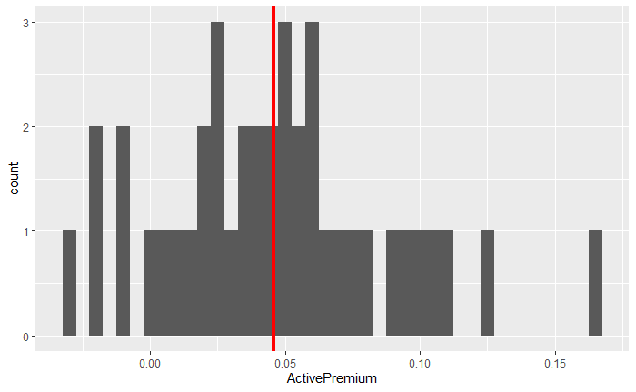

```r
RaRb_capm %>%
  ggplot(aes(x = ActivePremium)) +
  geom_histogram(binwidth = 0.005) +
  geom_vline(aes(xintercept = median(ActivePremium)), col = "red", size = 1.5)
```

## Analysis of Temporal Cluster Stability

Another question we had was whether symbols that get clustered together when looking at the complete time frame of available data, show changing cluster membership when looking at them in sliding windows. We decided to look at sliding windows of three years as those are wide enough to span complete recession events (at least in many cases).

```r
library(slider)

prices_index <- prices %>%
  arrange(ref.date) %>%
  (function(x) x$ref.date)

windowed_prices <- prices %>%
  tibble() %>%
  group_by(ticker) %>%
  arrange(ref.date) %>%
  slide_period(prices_index,
               "year",
               .f = (function(x) ungroup(x) %>% as_tsibble(index = ref.date, key = ticker)),
               .before = 2,
               .complete = TRUE)
```

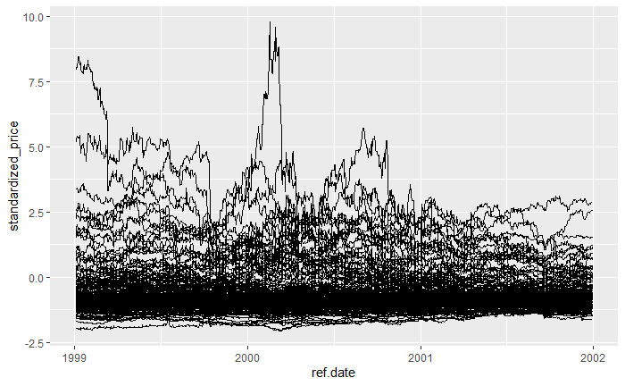

```r
price_range_1999_2001 <- windowed_prices[[3]]

price_range_1999_2001 %>%
  ggplot(aes(x = ref.date, standardized_price, group = ticker)) +
  geom_line()
```

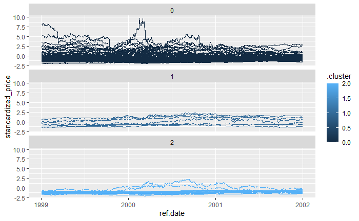

```r
test_window_prepped_data <- price_range_1999_2001 %>%
  features_for_price_range() %>%
  prepare_price_range(.rec = prep_rec) %>%
  extract_pca_components(pca_96_perc_rec)

test_window_clustered_data <- test_window_prepped_data %>%
  perform_clustering(.minPts = 5)

test_window_clustered_data %>%
  join_cluster_with_price_range(.price_range = price_range_1999_2001) %>%
  plot_clustered_tickers()
```

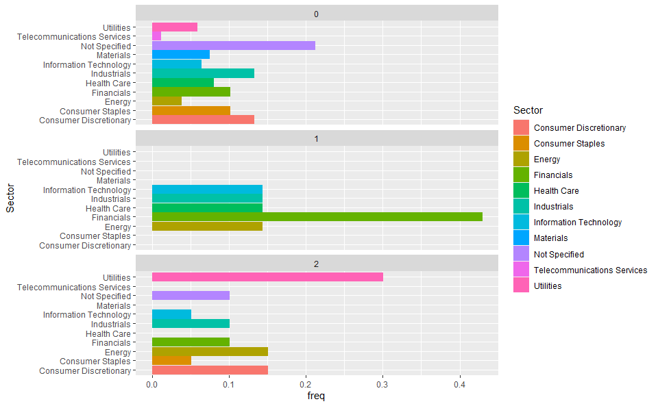

```r
test_window_clustered_data %>%
  enrich_with_meta() %>%
  sector_freq_per_cluster()
```

```r
performance_noise_cluster_test_window <- get_tickers_for_cluster(test_window_clustered_data, 0) %>%
  ticker_performance_against_baseline_in_range(price_range_1999_2001)

performance_noise_cluster_test_window
```

| ticker | ActivePremium | Alpha | AnnualizedAlpha | Beta | Beta- | Beta+ | Correlation | Correlationp-value | InformationRatio | R-squared | TrackingError | TreynorRatio |
| --- | --- | --- | --- | --- | --- | --- | --- | --- | --- | --- | --- | --- |
| AAPL | 0.0365 | 0.0268 | 0.3741 | 2.2015 | 1.0869 | 2.1297 | 0.5265 | 0.0012 | 0.0572 | 0.2772 | 0.6370 | 0.0092 |
| ABT | 0.0856 | 0.0077 | 0.0968 | 0.1379 | -0.1204 | 0.5564 | 0.0919 | 0.5997 | 0.2902 | 0.0084 | 0.2950 | 0.4593 |
| ADM | 0.0661 | 0.0079 | 0.0992 | 0.0263 | 0.4132 | -0.9409 | 0.0132 | 0.9400 | 0.1712 | 0.0002 | 0.3859 | 0.5924 |
| ADSK | -0.0284 | 0.0138 | 0.1786 | 0.9736 | -0.3858 | 0.1725 | 0.2451 | 0.1558 | -0.0434 | 0.0601 | 0.6542 | -0.0531 |
| AEE | 0.0742 | 0.0060 | 0.0745 | -0.1392 | -0.5978 | 0.3422 | -0.1027 | 0.5570 | 0.2479 | 0.0106 | 0.2995 | -0.4668 |
| AEP | 0.0384 | 0.0042 | 0.0513 | -0.3358 | -0.6936 | 0.9930 | -0.1981 | 0.2541 | 0.1062 | 0.0392 | 0.3614 | -0.0923 |
| AIT | 0.1450 | 0.0153 | 0.1995 | 0.0265 | 0.0697 | -0.3331 | 0.0118 | 0.9465 | 0.3471 | 0.0001 | 0.4178 | 4.6441 |
| ALL | 0.0015 | 0.0048 | 0.0596 | 0.1148 | -0.6257 | 1.7537 | 0.0485 | 0.7821 | 0.0034 | 0.0024 | 0.4313 | -0.2474 |
| AMAT | 0.2471 | 0.0361 | 0.5298 | 2.4097 | 2.4707 | 1.9080 | 0.6353 | 0.0000 | 0.4463 | 0.4036 | 0.5537 | 0.0907 |
| AMD | 0.0145 | 0.0337 | 0.4892 | 2.4582 | 2.7723 | 2.9983 | 0.4564 | 0.0059 | 0.0170 | 0.2083 | 0.8493 | 0.0173 |

[output cut: 179 more lines]

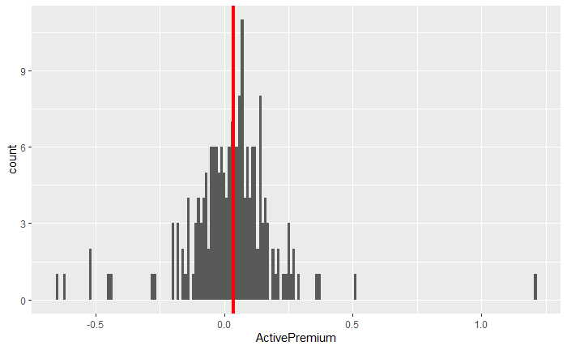

```r
performance_noise_cluster_test_window %>%
  ggplot(aes(x = ActivePremium)) +
  geom_histogram(binwidth = 0.01) +
  geom_vline(aes(xintercept = median(ActivePremium)), col = "red", size = 1.5)
```

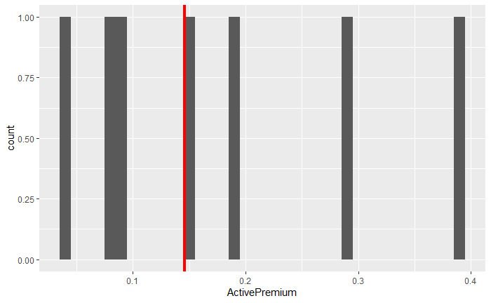

```r
get_tickers_for_cluster(test_window_clustered_data, 1) %>%
  ticker_performance_against_baseline_in_range(price_range_1999_2001) %>%
  ggplot(aes(x = ActivePremium)) +
  geom_histogram(binwidth = 0.01) +
  geom_vline(aes(xintercept = median(ActivePremium)), col = "red", size = 1.5)
```

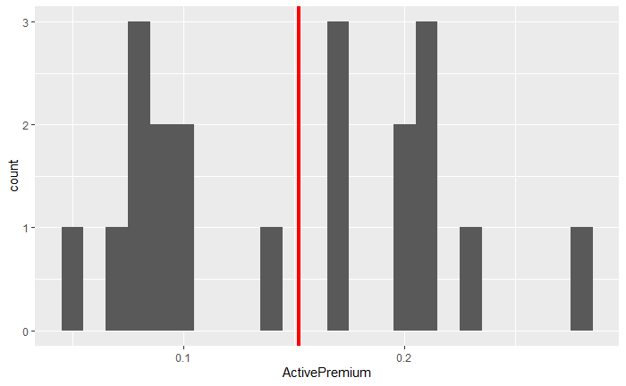

```r
get_tickers_for_cluster(test_window_clustered_data, 2) %>%
  ticker_performance_against_baseline_in_range(price_range_1999_2001) %>%
  ggplot(aes(x = ActivePremium)) +
  geom_histogram(binwidth = 0.01) +
  geom_vline(aes(xintercept = median(ActivePremium)), col = "red", size = 1.5)
```

```r
cluster_price_range <- function(.price_range) {
  unclustered_ticker_graph <- .price_range %>%
    ggplot(aes(x = ref.date, standardized_price, group = ticker)) +
    geom_line()

  price_range_prepped_data <- .price_range %>%
    features_for_price_range() %>%
    prepare_price_range(.rec = prep_rec) %>%
    extract_pca_components(pca_96_perc_rec)

  price_range_clustered_data <- price_range_prepped_data %>%
    perform_clustering(.minPts = 5)

  clustered_ticker_graph <- price_range_clustered_data %>%
    join_cluster_with_price_range(.price_range = .price_range) %>%
    plot_clustered_tickers()

  clustered_sector_composition <- price_range_clustered_data %>%
    enrich_with_meta() %>%
    sector_freq_per_cluster()

  list(price_range = .price_range,
       unclustered_graph = unclustered_ticker_graph,
       clustered_data = price_range_clustered_data,
       clustered_graph = clustered_ticker_graph,
       clustered_sectors = clustered_sector_composition)
}

clustered_price_windows <- prices %>%
  tibble() %>%
  group_by(ticker) %>%
  arrange(ref.date) %>%
  slide_period(prices_index,
               "year",
               .f = (function(x) ungroup(x) %>%
                       as_tsibble(index = ref.date, key = ticker) %>%
                       cluster_price_range()),
               .before = 7,
               .complete = TRUE)
```

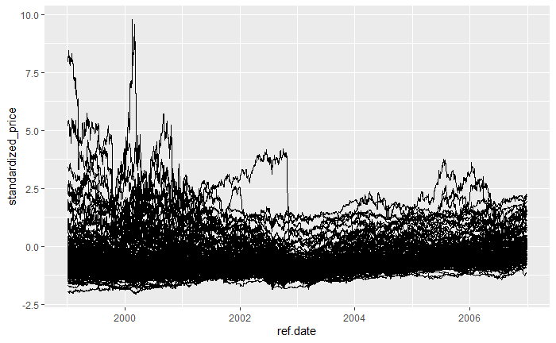

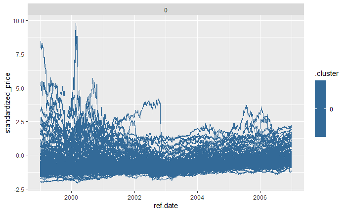

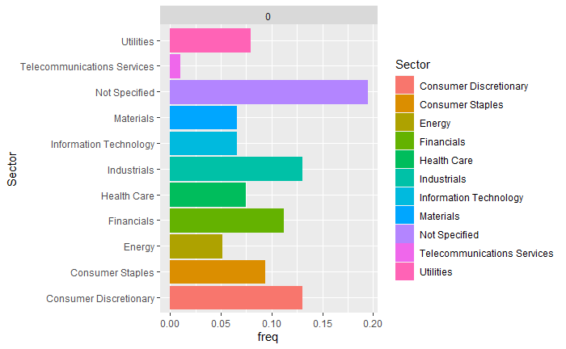

```r
print_window_graphs <- function(window) {
  window$unclustered_graph %>% print()
  window$clustered_graph %>% print()
  window$clustered_sectors %>% print()
}

clustered_price_windows[[8]] %>% print_window_graphs()
```

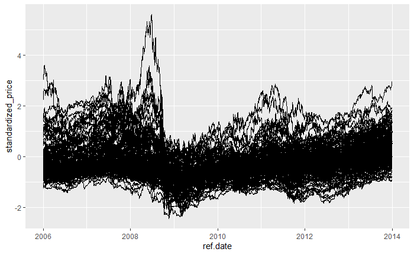

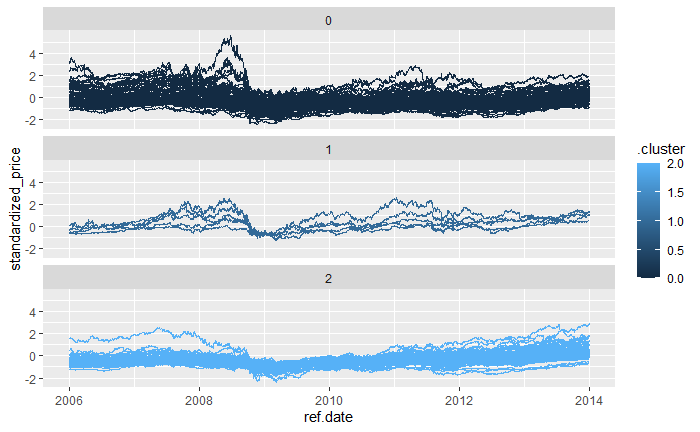

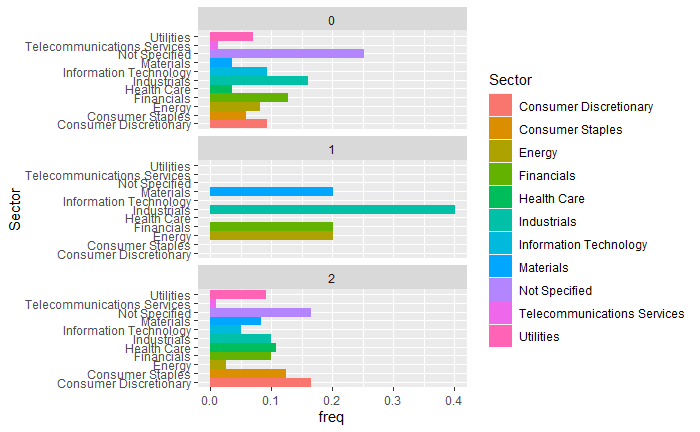

```r
clustered_price_windows[[15]] %>% print_window_graphs()
```

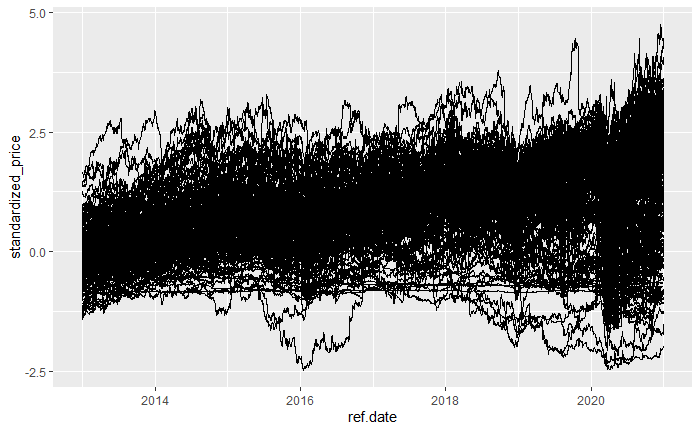

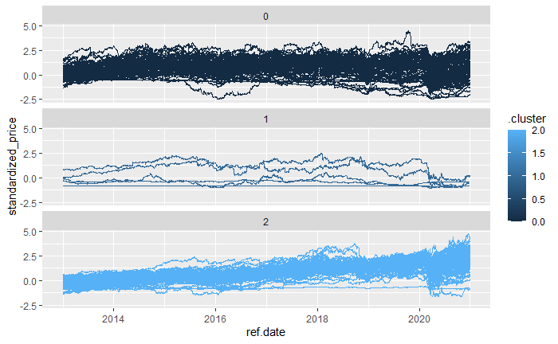

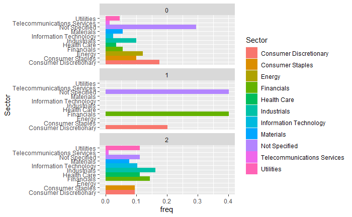

```r
clustered_price_windows[[22]] %>% print_window_graphs()
```

```r
label_for_price_range <- function(price_range) {
  min_year <- format(price_range$ref.date %>% min(), "%Y")
  max_year <- format(price_range$ref.date %>% max(), "%Y")
  paste(min_year, "_", max_year, sep = "")
}

extract_cluster_info <- function(window_results) {
  column_label <- label_for_price_range(window_results$price_range)

  window_results$clustered_data %>%
    select(ticker, .cluster) %>%
    rename_with(~ column_label, .cluster)
}

cluster_membership_over_time <- clustered_price_windows %>%
  compact() %>%
  lapply(extract_cluster_info) %>%
  reduce(inner_join, by = "ticker")

cluster_membership_over_time
```

| ticker | 1999_2006 | 2000_2007 | 2001_2008 | 2002_2009 | 2003_2010 | 2004_2011 | 2005_2012 | 2006_2013 | 2007_2014 | 2008_2015 | 2009_2016 | 2010_2017 | 2011_2018 | 2012_2019 | 2013_2020 | 2014_2021 |
| --- | --- | --- | --- | --- | --- | --- | --- | --- | --- | --- | --- | --- | --- | --- | --- | --- |
| AAPL | 0 | 0 | 2 | 2 | 0 | 0 | 3 | 2 | 2 | 0 | 0 | 2 | 2 | 0 | 2 | 4 |
| ABT | 0 | 0 | 2 | 2 | 0 | 0 | 0 | 2 | 2 | 0 | 2 | 2 | 2 | 0 | 2 | 4 |
| ADM | 0 | 0 | 2 | 2 | 3 | 2 | 0 | 0 | 2 | 0 | 0 | 2 | 2 | 0 | 0 | 1 |
| ADP | 0 | 0 | 0 | 0 | 0 | 0 | 3 | 2 | 2 | 0 | 2 | 2 | 2 | 2 | 2 | 4 |
| ADSK | 0 | 0 | 2 | 2 | 0 | 0 | 0 | 0 | 2 | 0 | 0 | 2 | 2 | 0 | 2 | 4 |
| AEE | 0 | 0 | 2 | 2 | 2 | 0 | 0 | 2 | 0 | 0 | 2 | 2 | 2 | 2 | 2 | 4 |
| AEP | 0 | 0 | 0 | 2 | 3 | 2 | 2 | 2 | 2 | 3 | 2 | 2 | 0 | 0 | 2 | 4 |
| AIG | 0 | 0 | 0 | 0 | 0 | 0 | 0 | 0 | 0 | 0 | 0 | 2 | 2 | 0 | 1 | 0 |
| AIT | 0 | 0 | 2 | 2 | 3 | 0 | 0 | 2 | 2 | 0 | 1 | 2 | 2 | 0 | 0 | 4 |
| ALL | 0 | 0 | 2 | 0 | 0 | 0 | 0 | 2 | 0 | 0 | 2 | 2 | 2 | 1 | 2 | 4 |

[output cut: 206 more lines]

```r
cluster_membership_stats <- cluster_membership_over_time %>%
  pivot_longer(cols = c(everything(), -ticker), names_to = "window", values_to = "cluster") %>%
  group_by(ticker) %>%
  summarise(memberships = length(unique(cluster)),
            outlier_count = sum(cluster == 0),
            first_count = sum(cluster == 1),
            second_count = sum(cluster == 2),
            third_count = sum(cluster == 3),
            fourth_cluster = sum(cluster == 4)) %>%
  filter(memberships > 1) %>%
  arrange(outlier_count)

cluster_membership_stats
```

| ticker | memberships | outlier_count | first_count | second_count | third_count | fourth_cluster |
| --- | --- | --- | --- | --- | --- | --- |
| CI | 5 | 3 | 2 | 9 | 1 | 1 |
| ECL | 5 | 3 | 3 | 7 | 2 | 1 |
| TJX | 5 | 3 | 3 | 7 | 1 | 2 |
| CLX | 5 | 4 | 1 | 7 | 3 | 1 |
| COST | 5 | 4 | 2 | 8 | 1 | 1 |
| DOV | 4 | 4 | 2 | 9 | 0 | 1 |
| DTE | 5 | 4 | 1 | 9 | 1 | 1 |
| MCO | 4 | 4 | 1 | 10 | 0 | 1 |
| AEP | 4 | 5 | 0 | 8 | 2 | 1 |
| DUK | 5 | 5 | 1 | 7 | 1 | 2 |

[output cut: 202 more lines]

```r
group_cluster_mode <- function(cluster_vec) {
  cluster_vec %>%
    table() %>%
    sort(decreasing = TRUE) %>%
    (function(x) x[1]) %>%
    names() %>%
    as.numeric()
}

tickers_by_all_time_cluster <- cluster_membership_over_time %>%
  pivot_longer(cols = c(everything(), -ticker), names_to = "window", values_to = "cluster") %>%
  group_by(ticker) %>%
  summarise(mode_cluster = cluster %>% group_cluster_mode())

tickers_by_all_time_cluster
```

| ticker | mode_cluster |
| --- | --- |
| AAPL | 0 |
| ABT | 2 |
| ADM | 0 |
| ADP | 0 |
| ADSK | 0 |
| AEE | 2 |
| AEP | 2 |
| AIG | 0 |
| AIT | 0 |
| ALL | 0 |

[output cut: 206 more lines]

```r
get_cluster_performance <- function(window_result) {
  price_period <- label_for_price_range(window_result$price_range)

  window_result$clustered_data$.cluster %>%
    unique() %>%
    lapply((function(x) get_tickers_for_cluster(window_result$clustered_data, x) %>%
              ticker_performance_against_baseline_in_range(window_result$price_range) %>%
              (function(y) tibble(median_active_premium = median(y$ActivePremium, na.rm = TRUE),
                                  cluster = x,
                                  period = price_period)))) %>%
    reduce(bind_rows)
}

cluster_performances_per_period <- clustered_price_windows %>%
  compact() %>%
  lapply(get_cluster_performance) %>%
  reduce(bind_rows)

cluster_performances_per_period
```

| median_active_premium | cluster | period |
| --- | --- | --- |
| 0.05755 | 0 | 1999_2006 |
| 0.08995 | 0 | 2000_2007 |
| 0.11795 | 2 | 2001_2008 |
| -0.00010 | 0 | 2001_2008 |
| 0.13970 | 1 | 2001_2008 |
| 0.09285 | 2 | 2002_2009 |
| -0.01220 | 0 | 2002_2009 |
| -0.03740 | 1 | 2002_2009 |
| 0.03130 | 0 | 2003_2010 |
| 0.09420 | 3 | 2003_2010 |

[output cut: 41 more lines]

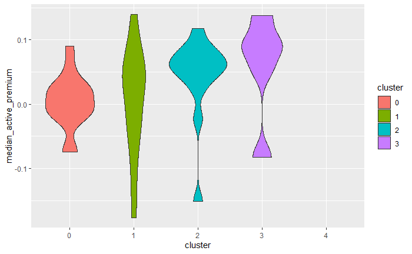

```r
cluster_performances_per_period %>%
  mutate(cluster = as_factor(cluster)) %>%
  ggplot(aes(x = cluster, y = median_active_premium, fill = cluster)) +
  geom_violin()
```

```r
cluster_of_interest <- prices %>%
  tibble() %>%
  left_join(tickers_by_all_time_cluster, by = "ticker") %>%
  left_join(ticker_meta, by = c("ticker" = "Symbol")) %>%
  filter(mode_cluster == 2) %>%
  as_tsibble(index = ref.date, key = ticker) %>%
  remove_empty(which = "cols")

cluster_of_interest
```

| ticker | ref.date | standardized_price | mode_cluster | Name | Exchange | Round.Lot.Size | Market.Category | Financial.Status | Sector | Subsector |
| --- | --- | --- | --- | --- | --- | --- | --- | --- | --- | --- |
| ABT | 1999-01-04 | -0.7182388 | 2 | Abbott Laboratories Common Stock | NYSE | 100 | NA | NA | Health Care | Health Care Equipment & Services |
| ABT | 1999-01-05 | -0.7175680 | 2 | Abbott Laboratories Common Stock | NYSE | 100 | NA | NA | Health Care | Health Care Equipment & Services |
| ABT | 1999-01-06 | -0.7215925 | 2 | Abbott Laboratories Common Stock | NYSE | 100 | NA | NA | Health Care | Health Care Equipment & Services |
| ABT | 1999-01-07 | -0.7282997 | 2 | Abbott Laboratories Common Stock | NYSE | 100 | NA | NA | Health Care | Health Care Equipment & Services |
| ABT | 1999-01-08 | -0.7303119 | 2 | Abbott Laboratories Common Stock | NYSE | 100 | NA | NA | Health Care | Health Care Equipment & Services |
| ABT | 1999-01-09 | -0.7303119 | 2 | Abbott Laboratories Common Stock | NYSE | 100 | NA | NA | Health Care | Health Care Equipment & Services |
| ABT | 1999-01-10 | -0.7303119 | 2 | Abbott Laboratories Common Stock | NYSE | 100 | NA | NA | Health Care | Health Care Equipment & Services |
| ABT | 1999-01-11 | -0.7370190 | 2 | Abbott Laboratories Common Stock | NYSE | 100 | NA | NA | Health Care | Health Care Equipment & Services |
| ABT | 1999-01-12 | -0.7417141 | 2 | Abbott Laboratories Common Stock | NYSE | 100 | NA | NA | Health Care | Health Care Equipment & Services |
| ABT | 1999-01-13 | -0.7239501 | 2 | Abbott Laboratories Common Stock | NYSE | 100 | NA | NA | Health Care | Health Care Equipment & Services |

[output cut: 990 more lines]

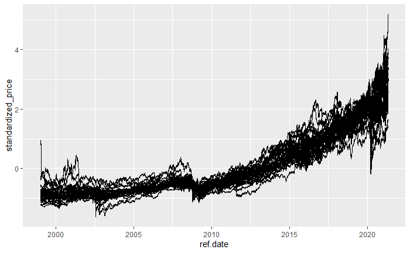

```r
cluster_of_interest %>%
  ggplot(aes(x = ref.date, standardized_price, group = ticker)) +
  geom_line()
```

```r
tickers_by_all_time_cluster %>%
  filter(mode_cluster == 2) %>%
  left_join(ticker_meta, by = c("ticker" = "Symbol")) %>%
  select(ticker, Name, Sector, Subsector)
```

| ticker | Name | Sector | Subsector |
| --- | --- | --- | --- |
| ABT | Abbott Laboratories Common Stock | Health Care | Health Care Equipment & Services |
| AEE | Ameren Corporation Common Stock | Utilities | MultiUtilities |
| AEP | American Electric Power Company, Inc. - Common Stock | Utilities | Electric Utilities |
| APD | Air Products and Chemicals, Inc. Common Stock | Materials | Industrial Gases |
| AVY | Avery Dennison Corporation Common Stock | Materials | Paper Packaging |
| BDX | Becton, Dickinson and Company Common Stock | Health Care | Health Care Equipment & Services |
| CI | Cigna Corporation Common Stock | Health Care | Managed Health Care |
| CLX | Clorox Company (The) Common Stock | Consumer Staples | Household Products |
| CNP | CenterPoint Energy, Inc (Holding Co) Common Stock | Utilities | MultiUtilities |
| COST | Costco Wholesale Corporation - Common Stock | Consumer Staples | Hypermarkets & Super Centers |

[output cut: 26 more lines]